# Heatmap and Network Analysis

Nat Pombubpa

6/4/2019

# This is a documentation for basic usage of heatmap and network analysis

Note: environmental data are imported with metadata/mapping file. This approach use phyloseq object and plot_ordination.

### STEP1: Load all necessary packages for analysis

More information about Phyloseq can be found at the following link: [Phyloseq](https://joey711.github.io/phyloseq/) If you get error in this step, you probably need to install any packages which causes error.

```r
library(ape)
library(vegan)
library(plyr)
library(dplyr)
library(scales)
library(grid)
library(reshape2)
library(phyloseq)
library(magrittr)
library(ggplot2)
library(ggpubr)
library(data.table)
library(SpiecEasi)
library(igraph)
```

### STEP2: Import Mapping file (metadate file)

1.Check mapping file before import to R, R will automatically change sample name that starts with number or contain “-” in sample name. If you get error in this step, you should check sample name first.

2.First column of first row should not start with #, R will not read the first row that starts with ‘#’

3.You can choose which samples to include in analysis by indicating specific group in the column

4.This mapping file had been modified to remove special characters in environmental data

```r
meta = read.table("FredMetaTest.txt",
                  header=TRUE,row.names=1,
                  sep="\t",stringsAsFactors=FALSE)
```

### STEP3: Construct sample_data-class using imported metadata

```r
sampleData <- sample_data(meta)
```

### STEP4: Import OTU table

OTU table from Jornada 16S data is “Pietras16S.otu_table.fix.txt”.

```r
otus <- read.table("Pietras16S.otu_table.fix.txt",
                   header=T,sep="\t",row.names = 1)
otumat <- as(as.matrix(otus), "matrix")
OTU = otu_table(otumat, taxa_are_rows = TRUE)
```

### STEP5: Import taxonomy table

Taxonmy table generated from AMPtk need to be rearranged using following script.

“perl rdp_taxonmy2mat.pl<Input_taxonmy.txt>Output_taxonomy.txt”

rdp_taxonomy2mat.pl was created by Professor Jason E. Stajich

```r
taxmat <- read.table("Pietras16S.taxonomy.fix.txt",
                     header=T,sep="\t",row.names=1)
taxmat <- as(as.matrix(taxmat),"matrix")
TAX = tax_table(taxmat)
```

### STEP6: Import phylogenetic tree

Phylogenetic tree can also be include for furthur phylogenetic analysis. The tree was generated when we run AMPtk on Discovery and can be dowload using Rsync.

Rsync -ai yourusername[AT]discovery.nmsu.edu:/PATH_to_File PATH_to_Working_Directory

```r
treefile = "Pietras16S.tree.phy"
tree = read.tree(treefile)
```

### STEP7: Construct Phyloseq object

To construct phyloseq object, otu table, taxonomy table, and sampleData are required. Phylogenetic tree can be included, but it is not necessary for constructing phyloseq object. Construct Phyloseq object called “Physeq”

```r
physeq = phyloseq(OTU,TAX,sampleData,tree)
```

### STEP8: Check phyloseq object

This should indicate that your physeq is a “phyloseq-class experiment-level object”

```r
physeq
```

```
## phyloseq-class experiment-level object
## otu_table()   OTU Table:         [ 19279 taxa and 34 samples ]
## sample_data() Sample Data:       [ 34 samples by 25 sample variables ]
## tax_table()   Taxonomy Table:    [ 19279 taxa by 7 taxonomic ranks ]
## phy_tree()    Phylogenetic Tree: [ 19279 tips and 19278 internal nodes ]
```

### STEP9: Remove singletons

Remove any OTUs that present only one time.

```r
physeq.prune = prune_taxa(taxa_sums(physeq) > 1, physeq)
```

```r
physeq.prune
```

```
## phyloseq-class experiment-level object
## otu_table()   OTU Table:         [ 11292 taxa and 34 samples ]
## sample_data() Sample Data:       [ 34 samples by 25 sample variables ]
## tax_table()   Taxonomy Table:    [ 11292 taxa by 7 taxonomic ranks ]
## phy_tree()    Phylogenetic Tree: [ 11292 tips and 11291 internal nodes ]
```

### STEP10: Check read counts to check dataset

Check read counts: any samples that have very low reads should be removed. [Ref](http://evomics.org/wp-content/uploads/2016/01/phyloseq-Lab-01-Answers.html)

```r
readcount = data.table(as(sample_data(physeq.prune), "data.frame"),
                 TotalReads = sample_sums(physeq.prune),
                 keep.rownames = TRUE)
setnames(readcount, "rn", "SampleID")

#For plotting, use command below.
#SeqDepth = ggplot(readcount, aes(TotalReads)) + geom_histogram() + ggtitle("Sequencing Depth")
```

```r
readcount = readcount[order(readcount$TotalReads), c("SampleID", "TotalReads")]
```

```r
head(readcount)
```

```
##       SampleID TotalReads
## 1: N38.JOR.NPP      29454
## 2: N36.JOR.NPP      30823
## 3: N14.JOR.NPP      36644
## 4:  N1.JOR.NPP      36742
## 5: N22.JOR.NPP      37437
## 6: N10.JOR.NPP      39661
```

### STEP11:Rarefy OTUs to a minimum number of reads

Rarefy OTUs (remove any samples that has very low number of reads). In this case, no sample was remove because number of reads are over 20,000 however, sample.size was indicated to rarefy number reads to the smallest size (lowest number of reads).

```r
set.seed(711)
physeq.prune.rarefy = rarefy_even_depth(physeq.prune, sample.size = 29454, replace = FALSE, trimOTUs = TRUE)
```

```
## You set `rngseed` to FALSE. Make sure you've set & recorded
##  the random seed of your session for reproducibility.
## See `?set.seed`
```

```
## ...
```

```
## 373OTUs were removed because they are no longer
## present in any sample after random subsampling
```

```
## ...
```

```r
physeq.prune.rarefy
```

```
## phyloseq-class experiment-level object
## otu_table()   OTU Table:         [ 10919 taxa and 34 samples ]
## sample_data() Sample Data:       [ 34 samples by 25 sample variables ]
## tax_table()   Taxonomy Table:    [ 10919 taxa by 7 taxonomic ranks ]
## phy_tree()    Phylogenetic Tree: [ 10919 tips and 10918 internal nodes ]
```

### STEP12: Heatmap (default)

We will use subset data to show heatmap default.

```r
Heatmap.physeq = prune_taxa(names(sort(taxa_sums(physeq.prune.rarefy),TRUE)[1:150]), physeq.prune.rarefy)
```

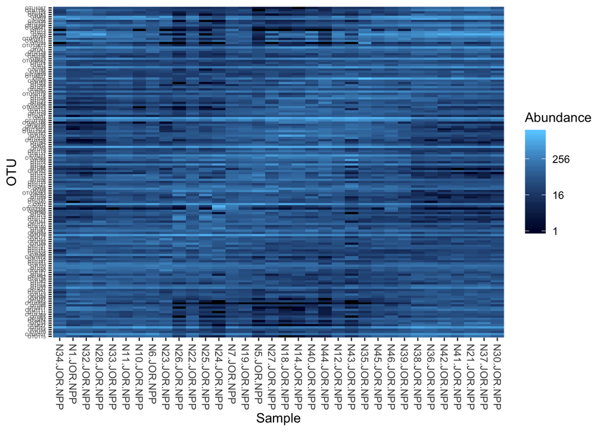

```r
plot_heatmap(Heatmap.physeq)
```

### STEP13: Specify details for your heatmap

Use “sample.label” to label each sample by site Use “taxa.lable” to label each OTU by it’s “Class” level. Use “title” to add plot title

Need more details? Please check following link [Ref](https://rdrr.io/bioc/phyloseq/man/plot_heatmap.html)

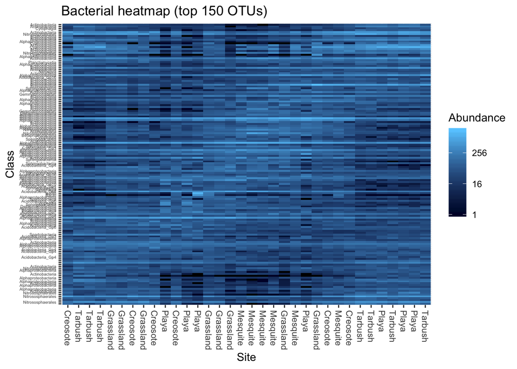

```r
plot_heatmap(Heatmap.physeq, sample.label = "Site", taxa.label = "Class", title = "Bacterial heatmap (top 150 OTUs)")
```

Use “sample.order” to reorder heatmap samples by Site

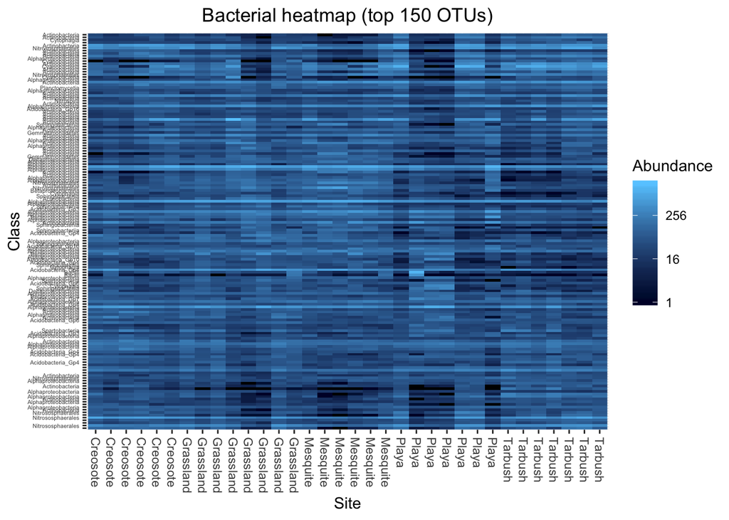

```r
plot_heatmap(Heatmap.physeq, sample.label = "Site", taxa.label = "Class",  sample.order = "Site", title = "Bacterial heatmap (top 150 OTUs)") + theme(plot.title = element_text(hjust = 0.5))
```